# HW6

Davis Vaughan

3/5/2018

# Required packages

```r
library(dplyr)
library(lubridate)
library(mvtnorm)
library(purrr)
library(readr)
library(tidyr)
options(pillar.sigfig = 6)
```

# Get data

```r
portfolio <- c("AAPL", "SPY")

# Dates
end_date   <- as.Date("2018-01-05")
start_date <- end_date - years(2) + days(2) # Add two days to get the correct 504 prices

# library(tidyquant)
# portfolio_raw  <- tq_get(portfolio,  from = start_date, to = end_date, get = "stock.prices.google")
# write_rds(portfolio_raw, "portfolio_raw.rds")
portfolio_raw <- read_rds("portfolio_raw.rds")
```

# Question 2

### Relative shifts

```r
portfolio_shifts <- portfolio_raw %>%
  group_by(symbol) %>%
  mutate(delta_X = close / lag(close) - 1) %>%
  select(symbol, date, delta_X) %>%
  spread(symbol, delta_X) %>%
  na.omit()

portfolio_shifts
```

```
## # A tibble: 503 x 3
##    date              AAPL          SPY
##    <date>           <dbl>        <dbl>
##  1 2016-01-08  0.00528771 -0.0109766
##  2 2016-01-11  0.0161922   0.000989996
##  3 2016-01-12  0.0145133   0.00806829
##  4 2016-01-13 -0.0257103  -0.0249406
##  5 2016-01-14  0.0218708   0.0164169
##  6 2016-01-15 -0.0240153  -0.0214662
##  7 2016-01-19 -0.00483888  0.00133113
##  8 2016-01-20  0.00134492 -0.0128151
##  9 2016-01-21 -0.00506251  0.00560194
## 10 2016-01-22  0.0531672   0.0205153
## # ... with 493 more rows
```

### Function for Empirical CDF

$$\hat{F}_n(t) = \frac{1}{n} \sum_{i = 1}^{n}{1_{x_i \le t}}$$

```r
cdf_empirical <- function(x) {
  rank(x) / length(x)
}
```

Here are the plots of the CDF’s to prove that this works

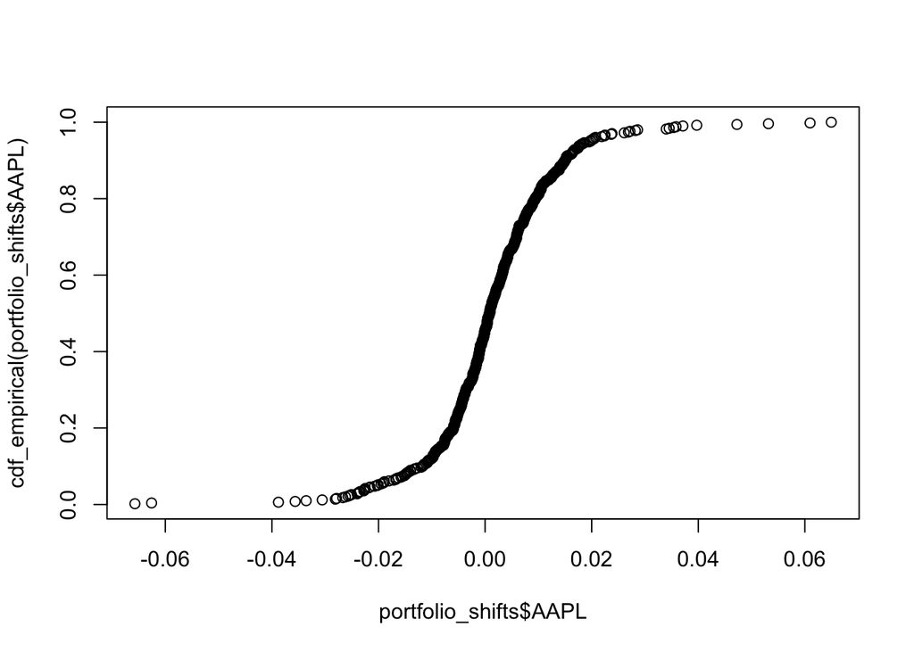

```r
plot(portfolio_shifts$AAPL, cdf_empirical(portfolio_shifts$AAPL))
```

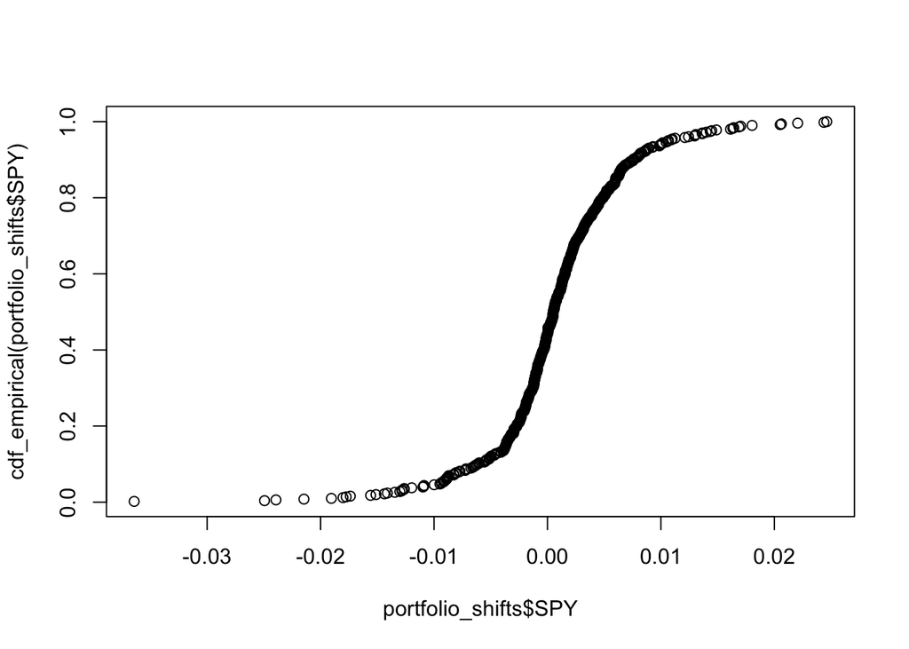

```r
plot(portfolio_shifts$SPY,  cdf_empirical(portfolio_shifts$SPY))
```

### Function for Gaussian Copula

```r
gaussian_copula_mvtnorm <- function(u1, u2, rho) {

  # Function that integrates the bivariate normal PDF
  # in a way that calculates the joint CDF.
  integrate_bivariate_normal <- function(x, y) {
    pmvnorm(lower = c(-Inf, -Inf),
            upper = c(x, y),
            corr  = matrix(c(1, rho, rho, 1), nrow = 2))
  }

  # This actually calculates the copula
  # Phi_p (Phi^-1 (u1), Phi^-1 (u2))
  integrate_bivariate_normal(qnorm(u1), qnorm(u2))
}
```

### Function for Joint CDF from gaussian copula

```r
joint_cdf <- function(x, y, rho)  {
  cdf_x <- cdf_empirical(x)
  cdf_y <- cdf_empirical(y)
  map2_dbl(cdf_x, cdf_y, gaussian_copula_mvtnorm, rho = rho)
}
```

### Empirical correlation

```r
rho <- with(portfolio_shifts, cor(AAPL, SPY))
rho
```

```
## [1] 0.5374579
```

### Copula calculations to get the joint CDF

Let’s calculate each piece individually rather than using `joint_cdf()` so you can see what is going on.

```r
portfolio_copula <- portfolio_shifts %>%
  mutate(
    F1_AAPL    = cdf_empirical(AAPL),
    F2_SPY     = cdf_empirical(SPY),
    joint_cdf  = map2_dbl(F1_AAPL, F2_SPY, gaussian_copula_mvtnorm, rho = rho)
  )

portfolio_copula
```

```
## # A tibble: 503 x 6
##    date              AAPL          SPY   F1_AAPL     F2_SPY  joint_cdf
##    <date>           <dbl>        <dbl>     <dbl>      <dbl>      <dbl>
##  1 2016-01-08  0.00528771 -0.0109766   0.675944  0.0397614  0.0385493
##  2 2016-01-11  0.0161922   0.000989996 0.916501  0.548708   0.535372
##  3 2016-01-12  0.0145133   0.00806829  0.890656  0.910537   0.835351
##  4 2016-01-13 -0.0257103  -0.0249406   0.0218688 0.00397614 0.00123284
##  5 2016-01-14  0.0218708   0.0164169   0.962227  0.984095   0.951214
##  6 2016-01-15 -0.0240153  -0.0214662   0.0278330 0.00795229 0.00241523
##  7 2016-01-19 -0.00483888  0.00133113  0.246521  0.584493   0.208655
##  8 2016-01-20  0.00134492 -0.0128151   0.530815  0.0318091  0.0296397
##  9 2016-01-21 -0.00506251  0.00560194  0.238569  0.831014   0.231545
## 10 2016-01-22  0.0531672   0.0205153   0.996024  0.992048   0.988747
## # ... with 493 more rows
```

### Correlation comparison

We want to verify that the correlation obtained from the copula is close to the empirical correlation.

We need a function that can calculate the probability:

$$P(a \le x \le b , c \le y \le d)$$

```r
gaussian_copula_mvtnorm_box <- function(u1, u2, l1, l2, rho) {

  integrate_bivariate_normal <- function(x_upper, y_upper, x_lower, y_lower) {
    pmvnorm(lower = c(x_lower, y_lower),
            upper = c(x_upper, y_upper),
            corr  = matrix(c(1, rho, rho, 1), nrow = 2))
  }

  integrate_bivariate_normal(qnorm(u1), qnorm(u2), qnorm(l1), qnorm(l2))
}
```

We also need a function to calculate E(XY).

```r
calc_E_XY <- function(x, y, rho) {

  x_sort <- sort(x)
  y_sort <- sort(y)

  cdf_sorted_x <- cdf_empirical(x_sort)
  cdf_sorted_y <- cdf_empirical(y_sort)

  e_product <- 0
  sum_p     <- 0

  for(i in 2:503) {

    x_i   <- x_sort[i]
    px_i  <- cdf_sorted_x[i]
    px_i1 <- cdf_sorted_x[i-1]

    for(j in 2:503) {

      y_j   <- y_sort[j]
      py_j  <- cdf_sorted_y[j]
      py_j1 <- cdf_sorted_y[j-1]

      p <- gaussian_copula_mvtnorm_box(px_i, py_j, px_i1, py_j1, rho = rho)

      #http://www.maths.lth.se/matstat/kurser/mas213/riemannstieltjes.pdf
      # page 11
      # p <- gaussian_copula_mvtnorm(px_i,  py_j,  rho) -
      #      gaussian_copula_mvtnorm(px_i1, py_j,  rho) -
      #      gaussian_copula_mvtnorm(px_i,  py_j1, rho) +
      #      gaussian_copula_mvtnorm(px_i1, py_j1, rho)

      if(!is.nan(p)) {
        e_product <- e_product + x_i * y_j * p
        sum_p     <- sum_p + p
      }

    }
    #print(paste("i = ", i))
  }

  list(e_product = e_product[1], sum_p = sum_p[1])
}
```

```r
e_xy_list <- calc_E_XY(portfolio_shifts$AAPL, portfolio_shifts$SPY, rho)

E_XY <- e_xy_list$e_product
E_XY
```

```
## [1] 4.009575e-05
```

```r
E_X  <- with(portfolio_shifts, mean(AAPL))
E_Y  <- with(portfolio_shifts, mean(SPY))
SD_X <- with(portfolio_shifts, sd(AAPL))
SD_Y <- with(portfolio_shifts, sd(SPY))

# Correlation of the distribution using the copula
cor_distribution <- (E_XY - E_X * E_Y) / (SD_X * SD_Y)
cor_distribution
```

```
## [1] 0.4720087
```

```r
# VS rho
rho
```

```
## [1] 0.5374579
```

```r
# Also ensure that sum of the probabilities are ~1
e_xy_list$sum_p
```

```
## [1] 0.9961929
```

### Adjust the initial correlation

You can adjust the correlation to get pretty darn close. Here we start with the correlations `0.6074579` and we get a final correlation of `0.5350656` which is very close to the `rho` of `0.5374579`.

```r
rho_adjusted <- rho + .07

e_xy_list_adjusted <- calc_E_XY(portfolio_shifts$AAPL, portfolio_shifts$SPY, rho_adjusted)

# Correlation of the distribution using the copula
(e_xy_list_adjusted$e_product - E_X * E_Y) / (SD_X * SD_Y)
```

```
## [1] 0.5350656
```

# Question 3

### Absolute shifts

```r
portfolio_abs_shifts <- portfolio_raw %>%
  group_by(symbol) %>%
  mutate(delta_X = close - lag(close)) %>%
  select(symbol, date, delta_X) %>%
  spread(symbol, delta_X) %>%
  na.omit()

portfolio_abs_shifts
```

```
## # A tibble: 503 x 3
##    date            AAPL       SPY
##    <date>         <dbl>     <dbl>
##  1 2016-01-08  0.510000 -2.13000
##  2 2016-01-11  1.57000   0.190000
##  3 2016-01-12  1.43000   1.55000
##  4 2016-01-13 -2.57000  -4.83000
##  5 2016-01-14  2.13000   3.10000
##  6 2016-01-15 -2.39000  -4.12000
##  7 2016-01-19 -0.470000  0.250000
##  8 2016-01-20  0.130000 -2.41000
##  9 2016-01-21 -0.490000  1.04000
## 10 2016-01-22  5.12000   3.83000
## # ... with 493 more rows
```

### Optimize 1-D t distributions for each stock

Hold the mean and variance constant and optimizing the likelihood based on changing the `nu`.

```r
# Based on location scale distribution
# https://www.mathworks.com/help/stats/t-location-scale-distribution.html
t_dist_neg_log_lik <- function(nu, x) {
  # Enforce a "known" mu and sigma. Only optimize for nu
  sigma <- sqrt(var(x) * (nu - 2) / nu)
  mu    <- mean(x)
  likelihood <- gamma((nu + 1) / 2) / (sigma * sqrt(nu * pi) * gamma(nu / 2)) *
                (1 + ((x - mu) / sigma)^2 / nu) ^ (- (nu + 1) / 2)

  sum(-log(likelihood))
}

# Get the optimal nu value for each stock
optimal_nu <- list(
  AAPL = optimize(f        = t_dist_neg_log_lik,
                  interval = c(0, 10),
                  x        = portfolio_abs_shifts$AAPL)$minimum,

  SPY  = optimize(f        = t_dist_neg_log_lik,
                  interval = c(0, 10),
                  x        = portfolio_abs_shifts$SPY)$minimum
)

optimal_nu
```

```
## $AAPL
## [1] 3.452356
##
## $SPY
## [1] 3.552655
```

### Simulate 10,000 random vectors

```r
set.seed(12345)

n <- 10000

# Correlation to use
rho_abs <- with(portfolio_abs_shifts, cor(AAPL, SPY))
rho_abs
```

```
## [1] 0.514226
```

```r
# Cholesky matrix
corr_mat <- matrix(c(1, rho_abs, rho_abs, 1), nrow = 2)
A <- t(chol(corr_mat))
A
```

```
##          [,1]      [,2]
## [1,] 1.000000 0.0000000
## [2,] 0.514226 0.8576547
```

```r
# Correlated bivariate normals
Z_std <- matrix(rnorm(2 * n), nrow = 2)
Z <- t(A %*% Z_std)
head(Z)
```

```
##            [,1]        [,2]
## [1,]  0.5855288  0.90957102
## [2,] -0.1093033 -0.44515060
## [3,]  0.6058875 -1.24761544
## [4,]  0.6300986  0.08714245
## [5,] -0.2841597 -0.93458318
## [6,] -0.1162478  1.49884861
```

```r
# Get correlated uniform variables
U <- pnorm(Z)

# Use our optimal values of nu to convert to deltaX values for the t distribution
delta_X_AAPL <- qt(U[,1], df = optimal_nu$AAPL)
delta_X_SPY  <- qt(U[,2], df = optimal_nu$SPY)

# See that rank correlation is preserved through the transformations
cor(Z[,1], Z[,2], method = "spearman")
```

```
## [1] 0.490087
```

```r
cor(U[,1], U[,2], method = "spearman")
```

```
## [1] 0.490087
```

```r
cor(delta_X_AAPL, delta_X_SPY, method = "spearman")
```

```
## [1] 0.490087
```

### Put option pricing function

```r
put_option_pricer <- function(s, k, r, y, t, sigma) {

  d1 <- (log(s / k) + (r - y + sigma^2 / 2) * t) / (sigma * sqrt(t))
  d2 <- d1 - sigma * sqrt(t)

  V <- pnorm(-d2) * k * exp(-r * t) - s * exp(-y * t) * pnorm(-d1)

  V
}
```

### Applying the simulations

Calculate the change in the portfolio value for each simulation

```r
# 100 shares of SPY
shares_spy <- 100

# 400 European put options on Apple
options_appl   <- 400

# Parameters
time_to_expiry <- 1
sigma          <- .25    # volatility
k              <- 170    # strike
r              <- .012   # risk free int rate
y              <- .019   # div yield

# Percentiles needed
percentile_99 <- round(n * 0.01)
percentile_97 <- round(n * 0.03)

# Current prices and option values
current_aapl_price  <- last(filter(portfolio_raw, symbol == "AAPL")$close)
current_spy_price   <- last(filter(portfolio_raw, symbol == "SPY")$close)
current_aapl_option <- put_option_pricer(current_aapl_price, k, r, y, time_to_expiry, sigma)

# Calculate the change in each stock and the change in the portfolio
portfolio_delta_p <- tibble(delta_X_AAPL, delta_X_SPY) %>%
  mutate(
    shifted_aapl_price  = current_aapl_price + delta_X_AAPL,
    shifted_aapl_option = put_option_pricer(shifted_aapl_price, k, r, y, time_to_expiry, sigma),
    delta_p_aapl        = shifted_aapl_option - current_aapl_option,
    delta_p_spy         = delta_X_SPY,
    delta_p             = shares_spy * delta_p_spy + options_appl * delta_p_aapl
  )

portfolio_delta_p
```

```
## # A tibble: 10,000 x 7
##    delta_X_AAPL delta_X_SPY shifted_aapl_pr… shifted_aapl_op… delta_p_aapl
##           <dbl>       <dbl>            <dbl>            <dbl>        <dbl>
##  1     0.646847   1.04203            175.647          14.8309   -0.261997
##  2    -0.117517  -0.484738           174.882          15.1409    0.0479909
##  3     0.670682  -1.51865            175.671          14.8213   -0.271582
##  4     0.699213   0.0934715          175.699          14.8098   -0.283048
##  5    -0.307231  -1.07473            174.693          15.2186    0.125720
##  6    -0.124999   1.93558            174.875          15.1439    0.0510505
##  7     0.402579   0.704958           175.403          14.9294   -0.163488
##  8    -0.844459   0.339975           174.156          15.4404    0.347548
##  9    -1.01607   -0.828901           173.984          15.5118    0.418947
## 10     1.33732    0.943345           176.337          14.5552   -0.537656
## # ... with 9,990 more rows, and 2 more variables: delta_p_spy <dbl>,
## #   delta_p <dbl>
```

### 99% VaR

```r
portfolio_delta_p %>%
  pull(delta_p) %>%
  sort() %>%
  .[percentile_99]
```

```
## [1] -560.6969
```

### 97% ES

```r
portfolio_delta_p %>%
  pull(delta_p) %>%
  sort() %>%
  .[seq(percentile_97)] %>%
  mean()
```

```
## [1] -554.6095
```

### Log likelihood for the joint density

```r
log_lik_gaussian_cop_with_t_marginals <- function(x, y, df_x, df_y, rho) {
  cdf_matrix <- cbind(pt(x, df = df_x), pt(y, df = df_y))
  inv_cdf_norm <- qnorm(cdf_matrix)
  log_lik <- dmvnorm(inv_cdf_norm, mean = c(0,0), sigma = matrix(c(1,rho,rho,1), ncol = 2), log = TRUE)
  sum(log_lik)
}

llh <- log_lik_gaussian_cop_with_t_marginals(
  x    = portfolio_abs_shifts$AAPL,
  y    = portfolio_abs_shifts$SPY,
  df_x = optimal_nu$AAPL,
  df_y = optimal_nu$SPY,
  rho  = rho
)
```

We are doing the log likelihood. So “bigger”, towards 0, is better. This table compares the model from this HW with the ones from HW 3. This model significantly outperforms the others!

```r
llh_comparison <- tribble(
  ~model,              ~llh,
  "dirty-t_nu",       -1657.373,
  "dirty-t_nu+1",     -1663.675,
  "dirty-t_nu-1",     -1650.319,
  "EM algo",          -1667.551,
  "Gauss cop, t marg", llh
)

arrange(llh_comparison, desc(llh))
```

```
## # A tibble: 5 x 2
##   model                  llh
##   <chr>                <dbl>
## 1 Gauss cop, t marg -1342.51
## 2 dirty-t_nu-1      -1650.32
## 3 dirty-t_nu        -1657.37
## 4 dirty-t_nu+1      -1663.68
## 5 EM algo           -1667.55
```

The log likelihood for this model seems to be much better than the HW3 models! This would make sense as we allowed the individual stocks to be modeled by t distributions with their own degrees of freedom parameters.